# Splines. Also, RSV

## Agenda

- Intro to splines
- Modeling with splines
- Outbreak outcome estimation
- `pspline.inference` R package
- Application to RSV

## Intro to splines

## Splines: what are they?

A *spline* is a *piecewise polynomial* on \([a, b] \subset \mathbb{R}\). The points at which the polynomial *segments are joined* are called *knots*.

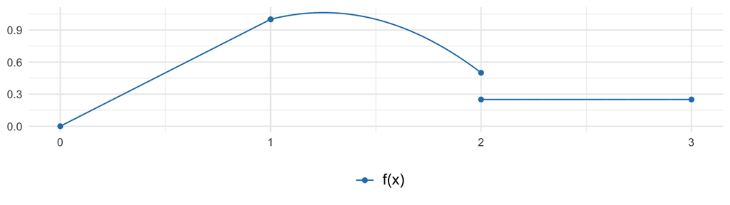

If \(P_i\) are *polynomials of degree ≤ m*, then the *spline* S has *degree m* and order m+1.

A spline is *continuous in all derivatives* everywhere *except* at its *knots*. At its knots a spline can have *continuity order* ranging from -1 (*no continuity*) through m-1.

## Spline degree 1, continuity -1

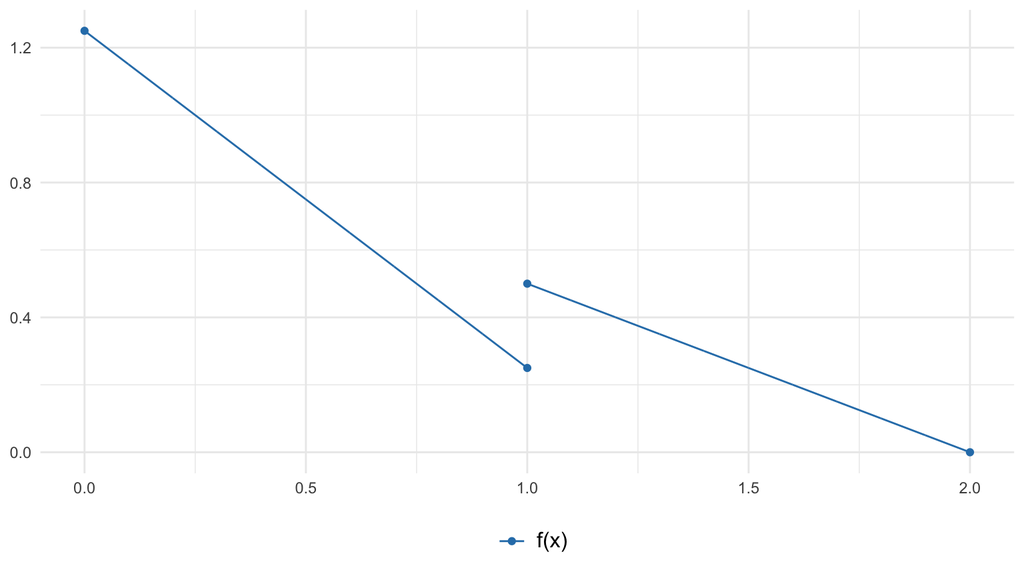

## Spline degree 1, continuity 0

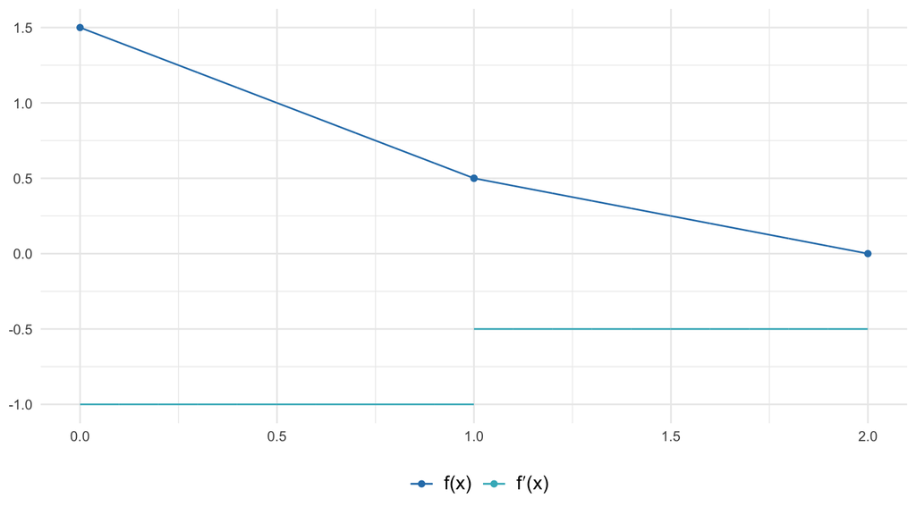

## Spline degree = 2, continuity -1

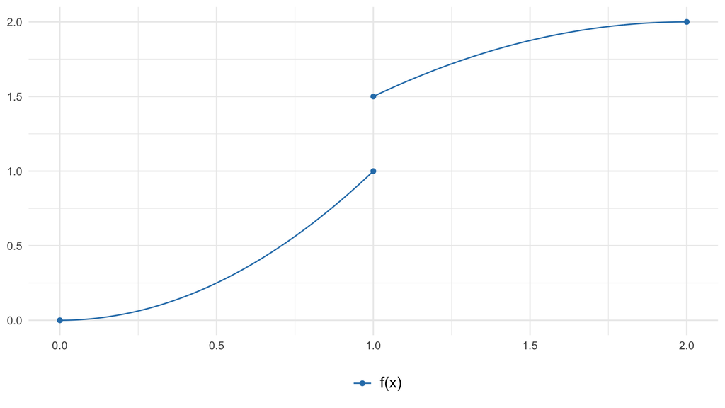

## Spline degree 2, continuity = 0

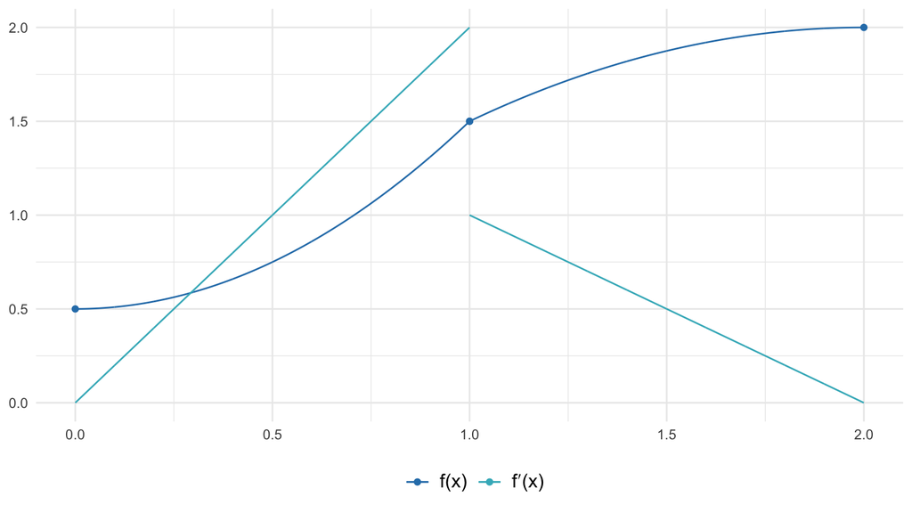

## Spline degree 2, continuity 1

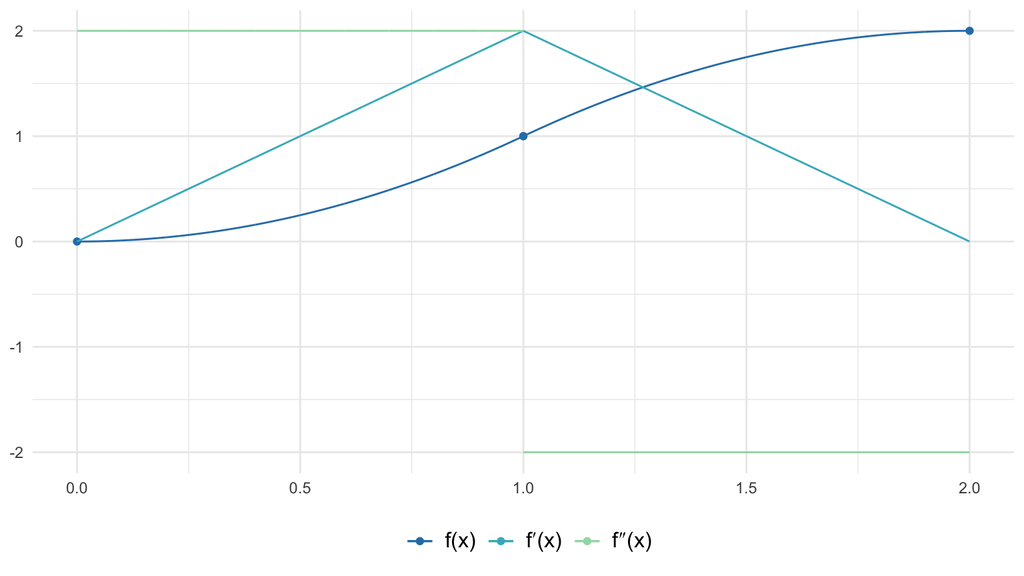

## Spline modeling

## Spline modeling

Goal: fit a spline to observations. *Cubic splines* are commonly used.

In a simple spline model, *quality of fit* is measured by *mean square error* (MSE).

## Linear spline model, 3 knots

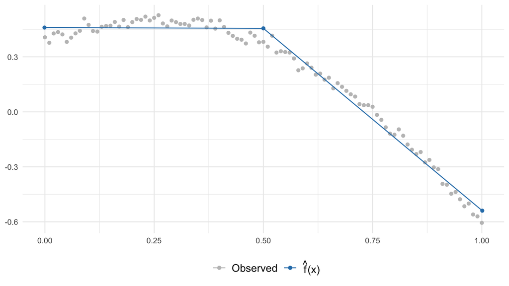

## Linear spline model, 10 knots

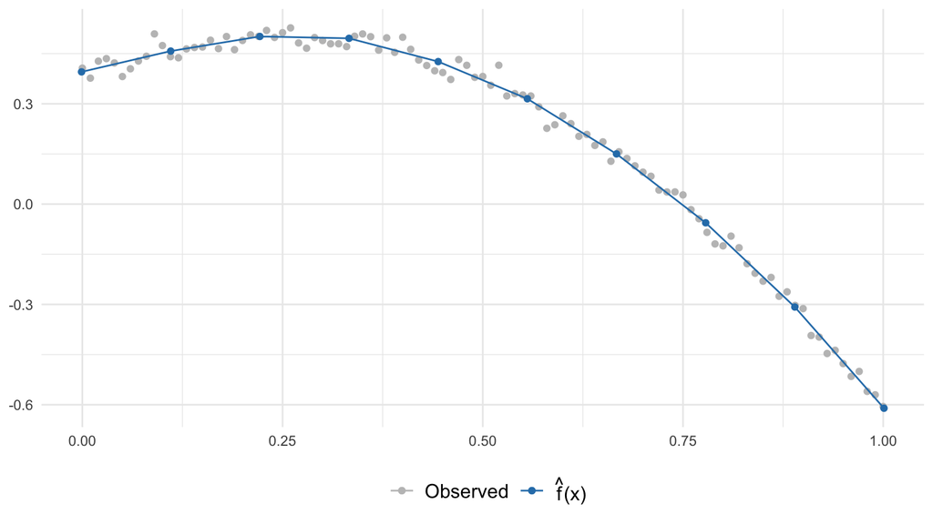

## Linear spline model, 20 knots

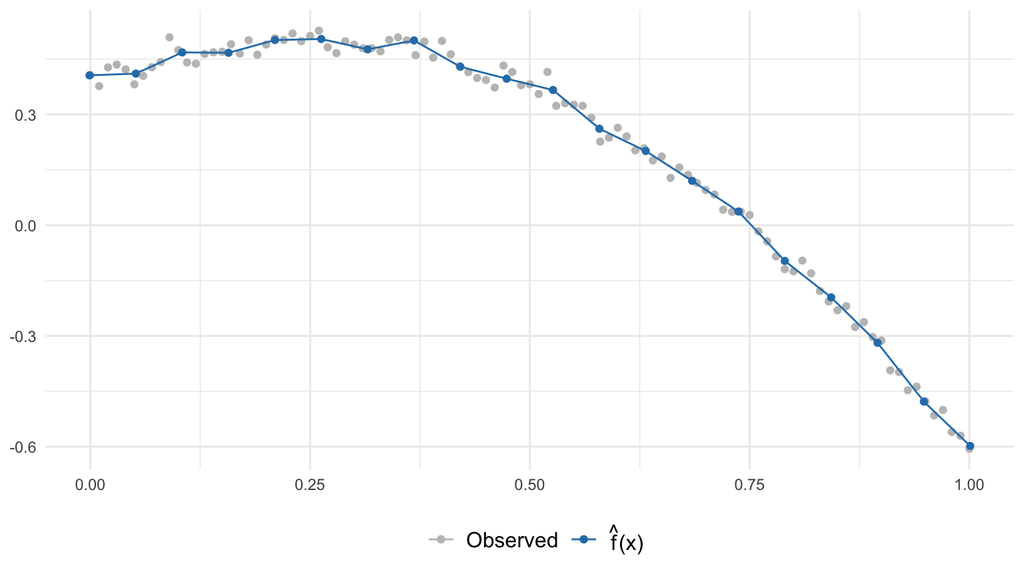

## Overfitting and penalties

Spline fitting with *MSE is sensitive to number of knots*. Too *many knots* lead to *overfitting*.

One solution to this problem is to include *smoothness* in *measure of fit*; this is known as *“penalty”*.

Most common penalty is *integral of second derivative squared*, also known as 2nd order penalty.

*Splines* used for fitting *with a penalty* term are known as *penalized splines*, or *P-splines*.

## Linear P-spline model, 20 knots

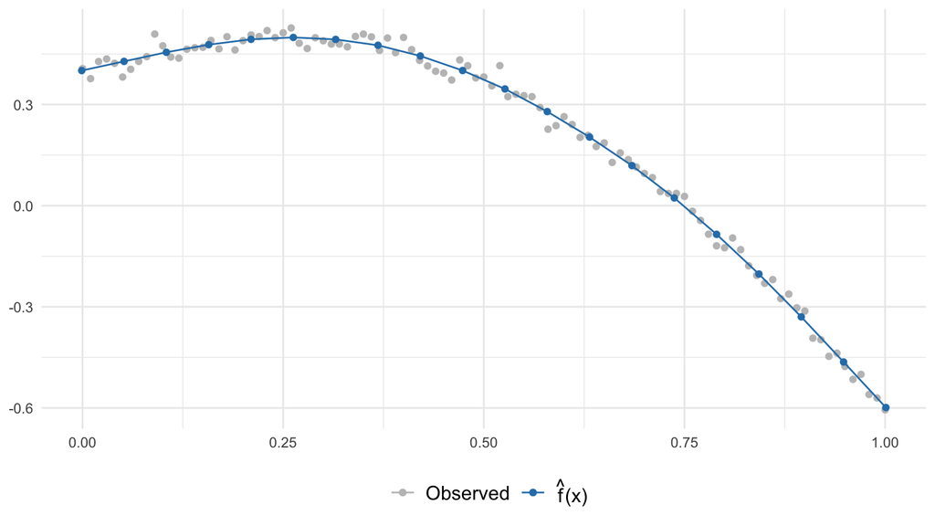

## Spline modeling: cyclic time

Splines *aren’t smooth* at the “ends” of a *time cycle*.

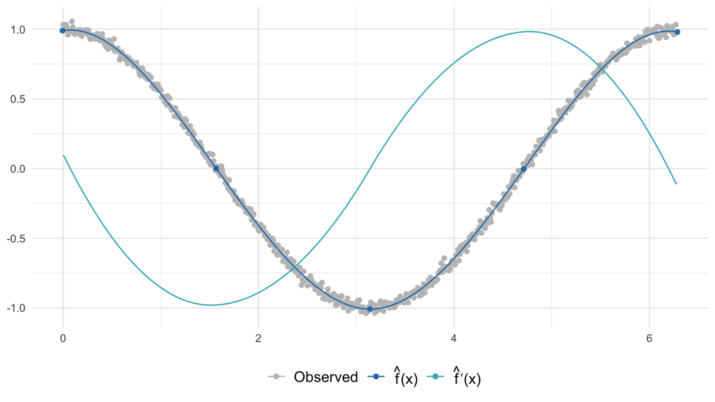

## Spline modeling: cyclic time

That is what *cyclic splines* are used for.

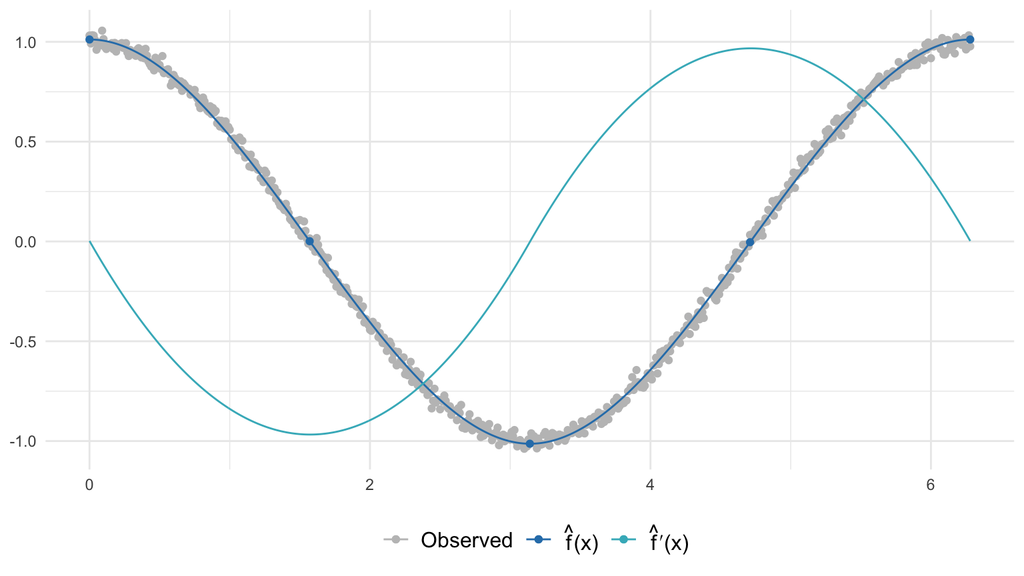

## Outbreak outcome estimation with P-splines

## 1. Define outcome measure

Onset = time corresponding to 2.5% of total cases

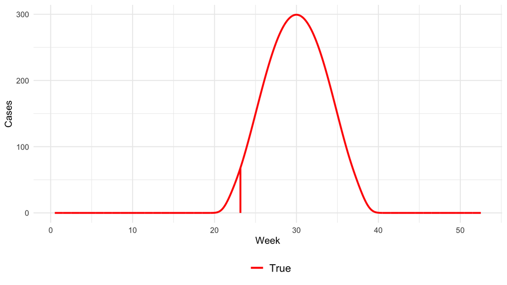

## 2. Fit a P-spline model

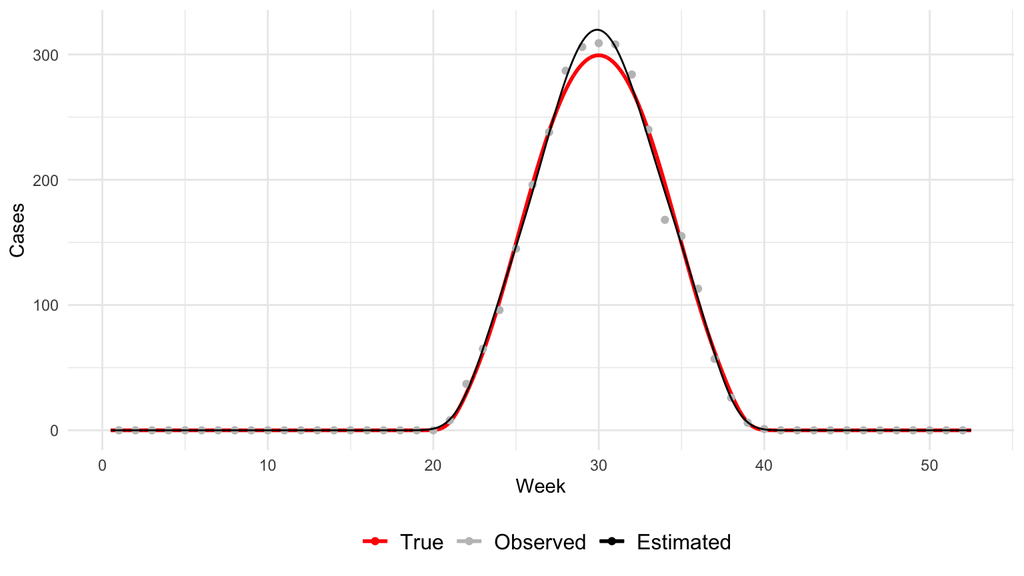

## 3. Sample model parameters

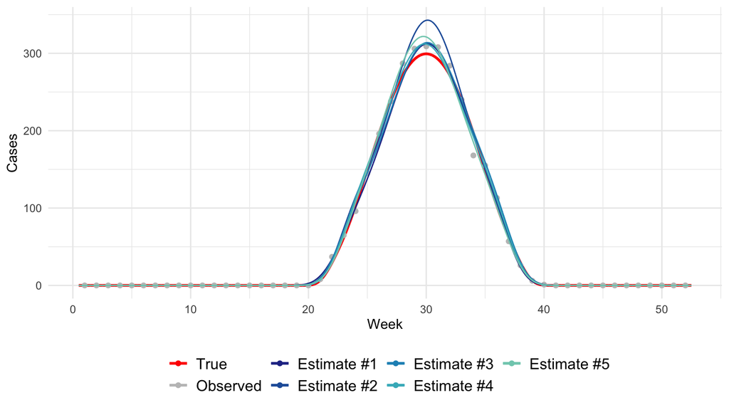

## 3. Sample model parameters

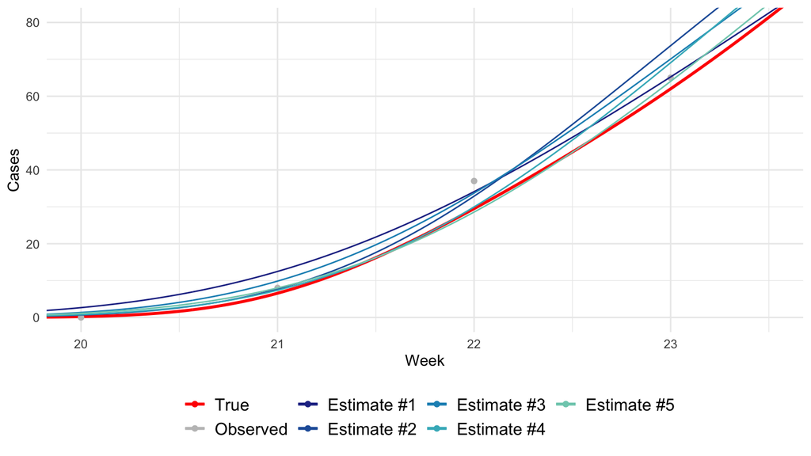

## 4. Sample outcome measure

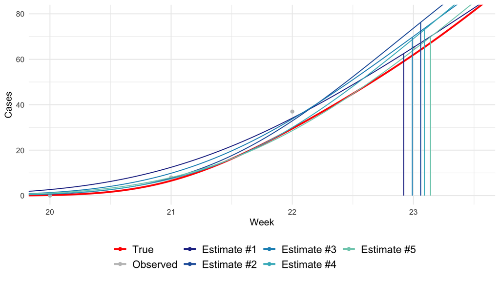

## 5. Infer outcome distribution

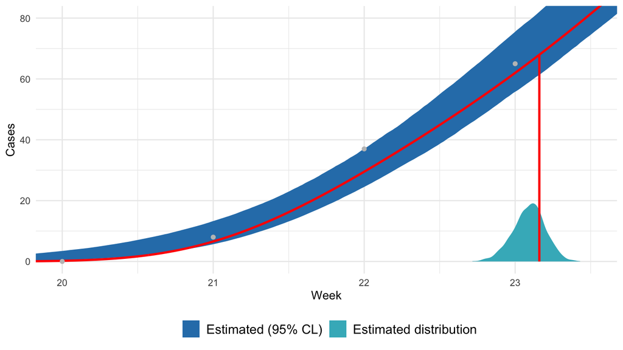

## `pspline.inference`

## `pspline.estimate.scalars`

- Set up a model:

```r
model <- gam(..., data)
```

- Provide outcome calculation from data:

```r
calc.outcome <- function(data) { ... }
```

- Get your estimates:

```r
outcome.estimate <- pspline.estimate.scalars(
  model, data, calc.outcome
)
```

## `pspline.validate.scalars`

- Generate simulated truth

```r
gen.truth <- function() { ... }
```

- Sample observations from truth

```r
gen.observations <- function(truth) { ... }
```

- Set up model for observations

```r
gen.model <- function(observations) { ... }
```

## `pspline.validate.scalars`

- Validate your outcome estimation

```r
validation <- pspline.validate.scalars(
  gen.truth, n.truth,
  gen.observations, n.observations,
  gen.model, calc.outcome
)
```

## RSV

## Motivation

*RSV* is one of the top infectious causes of *infant hospitalizations and mortality* in developed countries.

Effective *prophylaxis (palivizumab) is expensive*, and therefore only recommended during RSV season.

*Prophylaxis* guidelines (by American Academy of Pediatrics) use the *same schedule for all states* except for Florida.

Is that schedule a good match for the actual RSV season timing in CT?

## Motivation

[figure not shown]

## Questions

How many RSV cases occur during the AAP-recommended prophylaxis protection window?

How much can we increase that by adjusting the window based on state-level and county-level data?

## Approach

If prophylaxis lasts from \(T_\text{start}\) to \(T_\text{end}\), protected fraction is defined as:

\[ \begin{align} \text{protected } & \text{fraction}(T_\text{start}, T_\text{end}) = \\ &\frac{\text{RSV cases occurring beteween } T_\text{start} \text{ and } T_\text{end}}{\text{all RSV cases}} \end{align} \]

Using `pspline.inference`:

1. Estimate protected fraction for AAP prophlaxis guidelines.
2. Estimate protected fraction for alternate prophylaxis schedule — same duration, but lined up with RSV season and aligned to useful calendar intervals

## Results

Protected fraction of *AAP*-recommended prophylaxis is *94.08% statewide* (95% CI: 93.70 – 94.42%)

Rounding schedule to 4 weeks gives no benefit over AAP. (AAP is as good as it gets for month-based schedule in CT.)

Adjusting for year-to-year variation in RSV season timing doesn’t add any benefit.

## Conclusions

*Potential ~1% gain in protection* by adjusting prophylaxis schedule to match local (state or county) season timing (rounded to 1- or 2-week intervals).

*Need cost-benefit analysis* to weigh 1% improvement against implementation complexity.

Analysis method *generalizes to other states*.

`pspline.inference` *generalizes to other outcomes*.